# Regression Analysis: Linear Regression

Linear regression is a method used to predict the value of a variable using the value(s) of one or more predictor variables.

Goal: establish a linear relationship between the desired outcome variable and the predictors.

# 1 Simple Linear Regression

```r
cream.data <-
  data.frame(sunshines = c(2, 3, 5, 7, 9),
             creamsold = c(4, 5, 7, 10, 15))
cream.data
```

```
##   sunshines creamsold
## 1         2         4
## 2         3         5
## 3         5         7
## 4         7        10
## 5         9        15
```

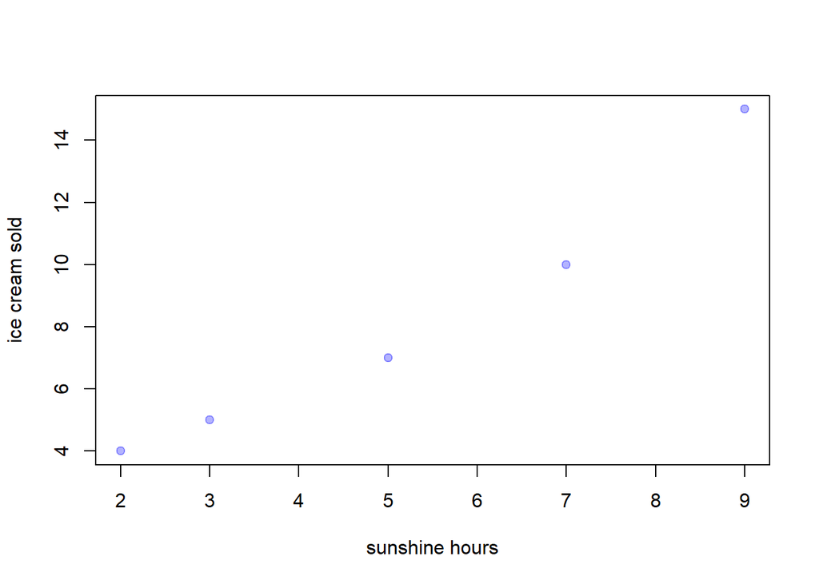

```r
## plot a x/y scatter plot with the data
library(scales)
plot(cream.data$sunshines, cream.data$creamsold, xlab = "sunshine hours", ylab = "ice cream sold",pch = 19, col=alpha("blue", 0.3))
```

```r
## create a "linear model" - that is, do the regression
cream.regression <- lm(creamsold ~ sunshines, data=cream.data)
## generate a summary of the regression
summary(cream.regression)
```

```
##
## Call:
## lm(formula = creamsold ~ sunshines, data = cream.data)
##
## Residuals:
##       1       2       3       4       5
##  0.6585  0.1402 -0.8963 -0.9329  1.0305
##
## Coefficients:
##             Estimate Std. Error t value Pr(>|t|)
## (Intercept)   0.3049     1.0435   0.292   0.7892
## sunshines     1.5183     0.1800   8.434   0.0035 **
## ---
## Signif. codes:  0 '***' 0.001 '**' 0.01 '*' 0.05 '.' 0.1 ' ' 1
##
## Residual standard error: 1.031 on 3 degrees of freedom
## Multiple R-squared:  0.9595, Adjusted R-squared:  0.946
## F-statistic: 71.13 on 1 and 3 DF,  p-value: 0.003498
```

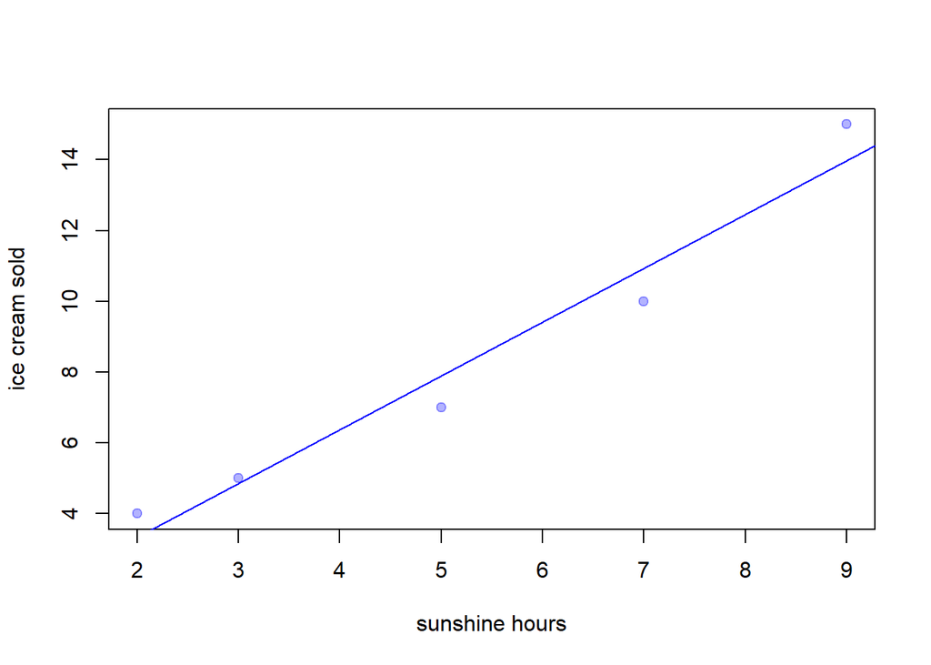

```r
plot(cream.data$sunshines, cream.data$creamsold, xlab = "sunshine hours", ylab = "ice cream sold",pch = 19, col=alpha("blue", 0.3))
## add the regression line to our x/y scatter plot
abline(cream.regression, col="blue")
```

```r
anova(cream.regression)
```

```
## Analysis of Variance Table
##
## Response: creamsold
##           Df Sum Sq Mean Sq F value   Pr(>F)
## sunshines  1 75.611  75.611  71.129 0.003498 **
## Residuals  3  3.189   1.063
## ---
## Signif. codes:  0 '***' 0.001 '**' 0.01 '*' 0.05 '.' 0.1 ' ' 1
```

Practice: Try the mouse data below. Use “mouse weight” to predict “mouse size”.

```r
mouse.data <- data.frame(
  weight=c(0.9, 1.8, 2.4, 3.5, 3.9, 4.4, 5.1, 5.6, 6.3),
  size=c(1.4, 2.6, 1.0, 3.7, 5.5, 3.2, 3.0, 4.9, 6.3))
mouse.data
```

```
##   weight size
## 1    0.9  1.4
## 2    1.8  2.6
## 3    2.4  1.0
## 4    3.5  3.7
## 5    3.9  5.5
## 6    4.4  3.2
## 7    5.1  3.0
## 8    5.6  4.9
## 9    6.3  6.3
```

```
##
## Call:
## lm(formula = size ~ weight, data = mouse.data)
##
## Residuals:
##     Min      1Q  Median      3Q     Max
## -1.5482 -0.8037  0.1186  0.6186  1.8852
##
## Coefficients:
##             Estimate Std. Error t value Pr(>|t|)
## (Intercept)   0.5813     0.9647   0.603   0.5658
## weight        0.7778     0.2334   3.332   0.0126 *
## ---
## Signif. codes:  0 '***' 0.001 '**' 0.01 '*' 0.05 '.' 0.1 ' ' 1
##
## Residual standard error: 1.19 on 7 degrees of freedom
## Multiple R-squared:  0.6133, Adjusted R-squared:  0.558
## F-statistic:  11.1 on 1 and 7 DF,  p-value: 0.01256
```

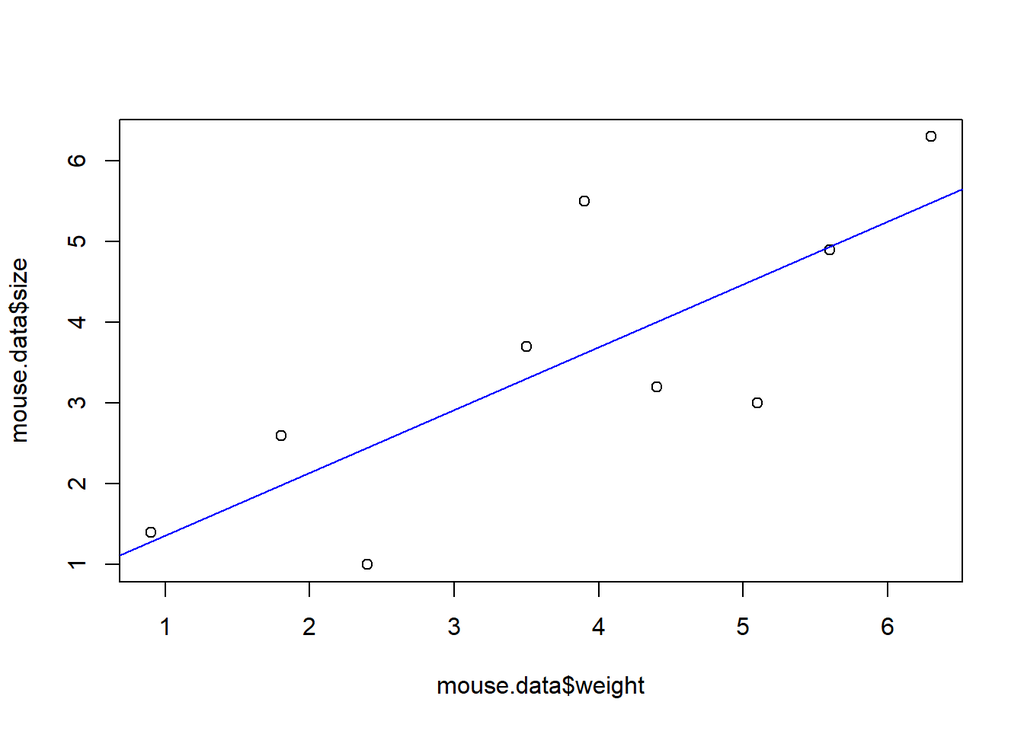

# 2 Multiple Linear Regression

In Multiple Linear Regression, we try to find the relationship between 2 or more independent variables (predictors) and the corresponding dependent variable (outcome).

## 2.1 Galton Dataset

```r
Galton <-  read.csv("http://cknudson.com/data/Galton.csv")
head(Galton)
```

```
##   FamilyID FatherHeight MotherHeight Gender Height NumKids
## 1        1         78.5         67.0      M   73.2       4
## 2        1         78.5         67.0      F   69.2       4
## 3        1         78.5         67.0      F   69.0       4
## 4        1         78.5         67.0      F   69.0       4
## 5        2         75.5         66.5      M   73.5       4
## 6        2         75.5         66.5      M   72.5       4
```

```r
names(Galton)
```

```
## [1] "FamilyID"     "FatherHeight" "MotherHeight" "Gender"       "Height"
## [6] "NumKids"
```

## 2.2 Model Assumptions

### 2.2.1 Linearity

It states that the dependent variable Y should be linearly related to independent variables. This assumption can be checked by plotting a scatter plot between both variables.

```r
attach(Galton)
model <- lm(Height~FatherHeight+MotherHeight)
```

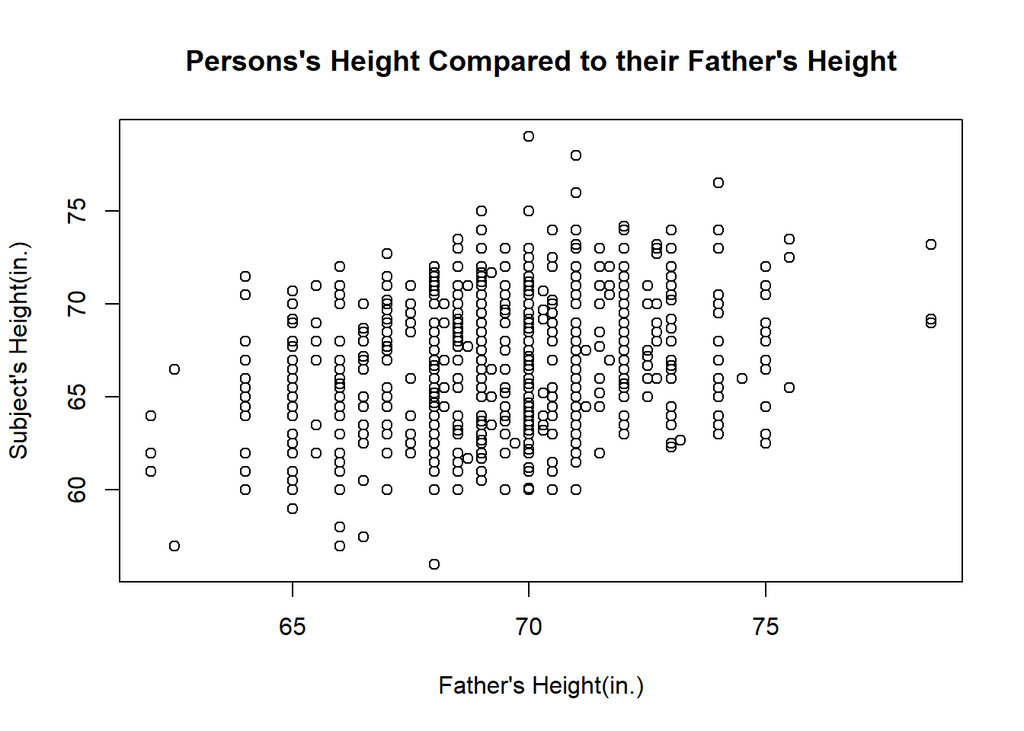

```r
## Creating a Scatterplot
plot(FatherHeight, Height, ylab = "Subject's Height(in.)",
     xlab = "Father's Height(in.)",
     main = "Persons's Height Compared to their Father's Height")
```

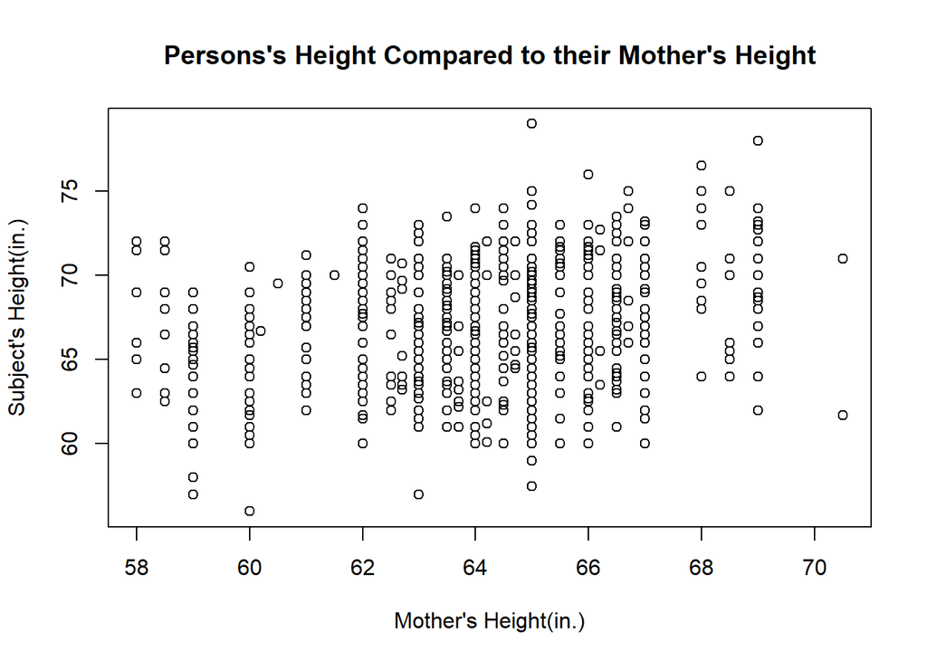

```r
plot(MotherHeight, Height, ylab = "Subject's Height(in.)",
     xlab = "Mother's Height(in.)",
     main = "Persons's Height Compared to their Mother's Height")
```

### 2.2.2 Homoscedasticity

The variance of the error terms should be constant i.e the spread of residuals should be constant for all values of X. This assumption can be checked by plotting a residual plot. If the assumption is violated, then the points will form a funnel shape otherwise they will be constant.

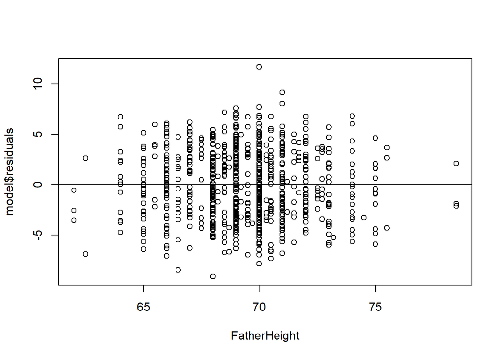

```r
##  plot our residuals along a horizontal line across 0.
plot(model$residuals ~ FatherHeight)
abline(0,0)
```

We will say this assumption is met as our plots give no evidence of different levels of variance.

### 2.2.3 Independence/No Multicollinearity

The variables should be independent of each other i.e. no correlation should be there between the independent variables. To check the assumption, we can use a correlation matrix or variance inflation factor (VIF) score. If the VIF score is greater than 5 then the variables are highly correlated.

```r
car::vif(model)
```

```
## FatherHeight MotherHeight
##     1.005456     1.005456
```

### 2.2.4 Normality

The error follows a normal distribution.

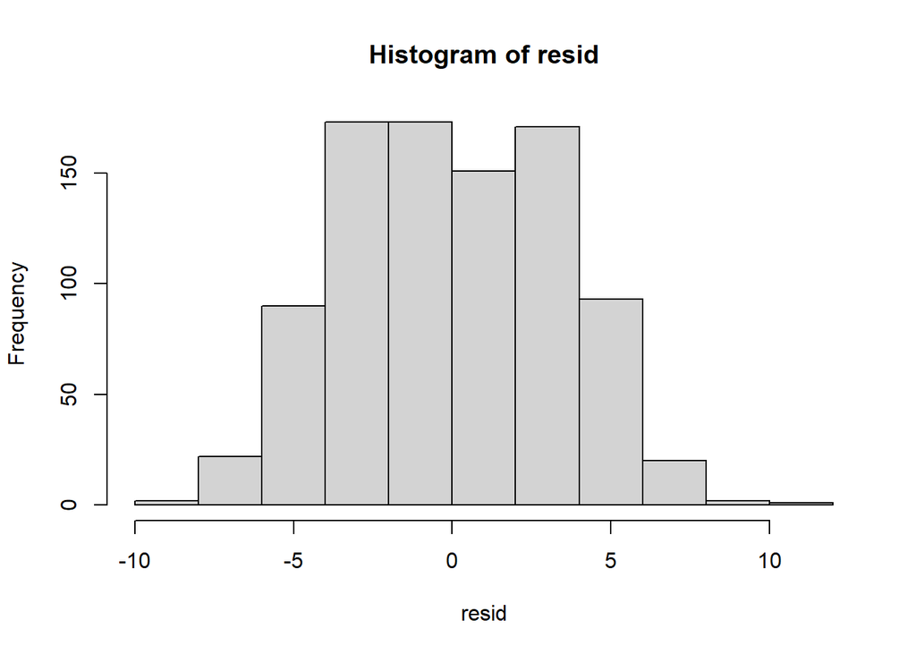

```r
resid<- model$residuals
hist(resid)
```

Another good way to look at this assumption is to plot our errors along a straight line in a quantile plot. If our error is normally distributed then they will follow the straight line.

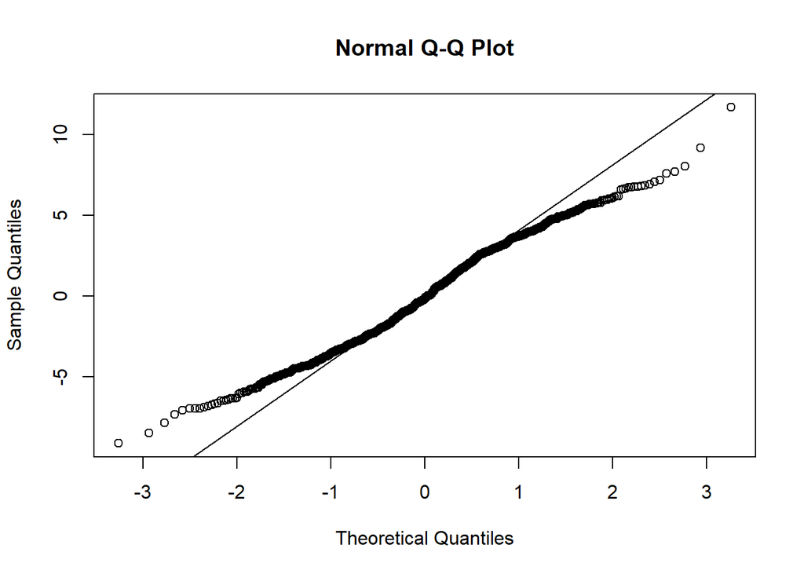

```r
qqnorm(resid)
qqline(resid)
```

## 2.3 Multiple Linear Regression

```r
attach(Galton)
model <- lm(Height~FatherHeight+MotherHeight)
summary(model)
```

```
##
## Call:
## lm(formula = Height ~ FatherHeight + MotherHeight)
##
## Residuals:
##    Min     1Q Median     3Q    Max
## -9.136 -2.700 -0.181  2.768 11.689
##
## Coefficients:
##              Estimate Std. Error t value Pr(>|t|)
## (Intercept)  22.30971    4.30690   5.180 2.74e-07 ***
## FatherHeight  0.37990    0.04589   8.278 4.52e-16 ***
## MotherHeight  0.28321    0.04914   5.764 1.13e-08 ***
## ---
## Signif. codes:  0 '***' 0.001 '**' 0.01 '*' 0.05 '.' 0.1 ' ' 1
##
## Residual standard error: 3.386 on 895 degrees of freedom
## Multiple R-squared:  0.1089, Adjusted R-squared:  0.1069
## F-statistic: 54.69 on 2 and 895 DF,  p-value: < 2.2e-16
```